# MATURITY SCALE TOOLS

#### *Last update : 08/08/2022*

**Choice of the output format :**

PDF

HTML

This tool is a **guide for identifying maturity phases of fish of commercial interest**. It was set up as part of the project to harmonize maturity data collection methods.

It is composed of identification sheets for males and females of each species of fish and provides simple comments and photos to ease the identification of maturity phases.

The maturity phases identification presented in this tools is exclusively based on visual criteria described by the **ICES 2012/2018 “WKMATCH” scale**. This scale was created in the ideal of a universal scale, regardless of the species or the sex of the individual. It also falls within the respect of the species biology.

This scale is divided into 6 maturity phases, corresponding to specific development periods of the gonads during the reproductive cycle :

### ICES maturity scale « WKMATCH 2012 and 2018 »

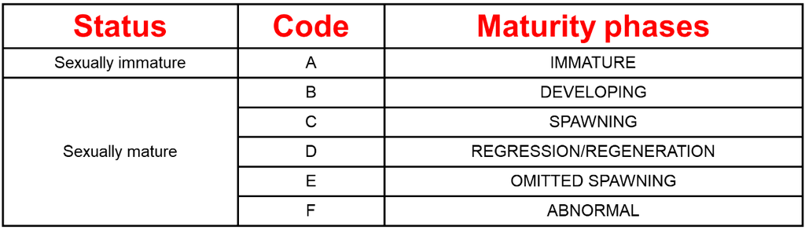

All photos have been taken based on the “Gonads’ photography protocol” established during the data collection process.

FISH GONADS’ PHOTOGRAPHY PROTOCOL

PDF / HTML

Go back

Anna LE MELEDER  
IFREMER / RBE-HMMN-LRHPB